# Setting up our scenes

In this part, we’re going to set up the scenes we need to design the lightning effect. By the end of the lesson, we’ll have a skeleton for the effect. We need three scenes:

- The *LightingJolt* creates a single lightning bolt-like shape, then destroys itself.
- The *LightningBeam* is responsible for creating multiple *LightingJolt* effects when fired.
- The *Ship* rotates and fires the *LightningBeam*.

We’ll build on these as we go, but let’s create stripped-down versions of them first so we can see how they interact with each other.

## Setting up the Lightning Jolt scene

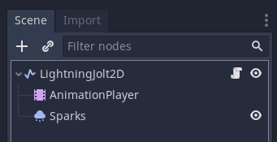

We’ll revisit the `LightningJolt.gd` script later, but let’s cache our *Sparks* particles and define a blank `create` function for now:

```
extends Line2D

onready var sparks := $Sparks


func create(start : Vector2, end : Vector2) -> void:
    pass
```

A lightning bolt is going to be a collection of jolts. We’ll call the above `create()` function in the `LightningBeam.gd` script, so let’s move onto the *LightningBeam* scene.

## Setting up the LightningBeam scene

Create a new scene with a `RayCast2D` as the root and attach a script. I renamed it *LightningBeam*.

[figure not shown]

There’s not too much to change in the settings: make sure it’s enabled and have it cast to the right. The `cast_to` is the range of the weapon. I set it to 600 pixels.

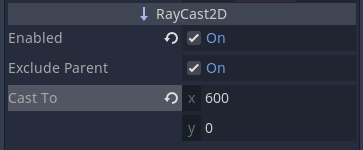

We need the lightning beam script to update the target point of the effect and create as many jolts we desire. To that end, we define several variables:

- `flashes` dictates how many jolts instances we create when firing the weapon.
- `flash_time` is the time interval between flashes.
- `lightning_jolt` is a reference to the `LightningJolt.tscn` packed scene. We load it at compile time for efficiency.
- `target_point` is the jolt’s end position.

We’ll be using the `_physics_process()` and `shoot()` functions in the future, so we add them here.

[output not shown]

## Setting up the Ship scene

For demonstration and testing, create a new scene with a `Node2D`as the root and call it “PlayerShip”. Add a script and a `Sprite` as a child.

[figure not shown]

Add a suitable ship sprite and rotate it so it points to the right to align it with the lightning beam’s direction.

[figure not shown]

Speaking of the lightning beam scene, we add an instance of it as a child by clicking the chain symbol below the Scene tab.

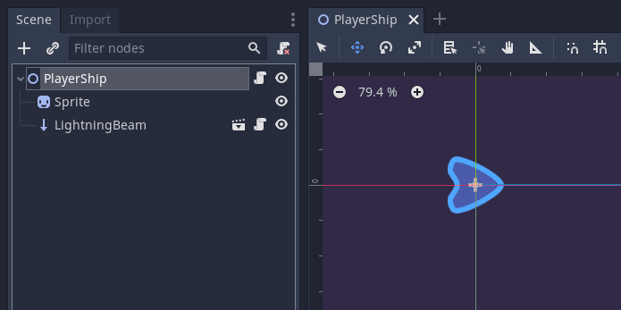

In the `PlayerShip.gd` script, we cache the lightning beam and update the ship’s rotation so it looks at the mouse cursor in the `_process()` function. Note that this also rotates the lightning beam because children inherit their parent’s rotation and position.

In the `_unhandled_input()` function we check if the `ui_accept` action is pressed. By default, this action corresponds to space or the return key. If it’s pressed, we call the shoot function of the LightningBeam.

```
extends Node2D

onready var lightning := $LightningBeam


func _process(_delta: float) -> void:
    look_at(get_global_mouse_position())


func _unhandled_input(event: InputEvent) -> void:
    if event.is_action_pressed("ui_accept"):
        lightning.shoot()
```

You can view other inputs by going to Project > Project Settings… > Input Map.

Move the player ship away from the viewport’s top-left corner and run the scene. If you move your cursor, you’ll see the ship follows it. However, pressing space does nothing yet because the functions are empty.

[figure not shown]

We’ve set up all our scenes and boilerplate code to handle interactions between them. In the next lesson, we’ll dive into the `LightningJolt.gd` script to generate the shape of the effect and eventually fire it!